# Detección de Bordes

Fundamentos y métodos

Author

Curso de Procesamiento Digital de Imágenes

## 1 ¿Qué es un borde?

- Un **borde** es una transición abrupta de intensidad en la imagen.
- Generalmente corresponde a límites de objetos.
- Detectar bordes es un paso clave en **segmentación** y **reconocimiento**.

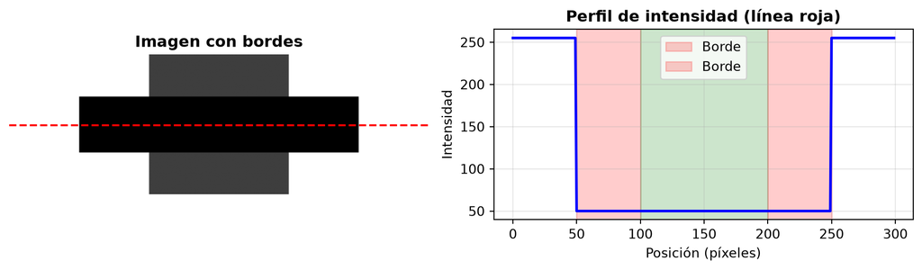

## 2 Gradientes

- Los bordes se relacionan con el **gradiente de la imagen**:
  $$\nabla I = \left( \frac{\partial I}{\partial x}, \frac{\partial I}{\partial y} \right)$$
- Magnitud del gradiente:
  $$|\nabla I| = \sqrt{\left(\frac{\partial I}{\partial x}\right)^2 + \left(\frac{\partial I}{\partial y}\right)^2}$$
- Dirección del gradiente:
  $$\theta(x,y)=\operatorname{atan2}\left(\frac{\partial I}{\partial y},\frac{\partial I}{\partial x}\right)$$
- En Canny, $\theta$ suele cuantizarse a $0^\circ, 45^\circ, 90^\circ, 135^\circ$ para aplicar **NMS**.

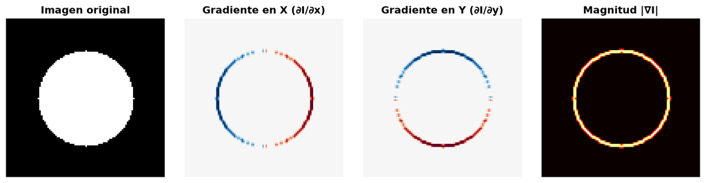

## 3 Operadores de Gradiente

Los gradientes se aproximan con **operadores de convolución**:

- **Roberts**
  $$R_x = \begin{bmatrix} 1 & 0 \\ 0 & -1 \end{bmatrix}, \quad
  R_y = \begin{bmatrix} 0 & 1 \\ -1 & 0 \end{bmatrix}$$
- **Prewitt**
  $$P_x = \begin{bmatrix} -1 & 0 & 1 \\ -1 & 0 & 1 \\ -1 & 0 & 1 \end{bmatrix}, \quad
  P_y = \begin{bmatrix} -1 & -1 & -1 \\ 0 & 0 & 0 \\ 1 & 1 & 1 \end{bmatrix}$$
- **Sobel** (más usado)
  $$S_x = \begin{bmatrix} -1 & 0 & 1 \\ -2 & 0 & 2 \\ -1 & 0 & 1 \end{bmatrix}, \quad
  S_y = \begin{bmatrix} -1 & -2 & -1 \\ 0 & 0 & 0 \\ 1 & 2 & 1 \end{bmatrix}$$

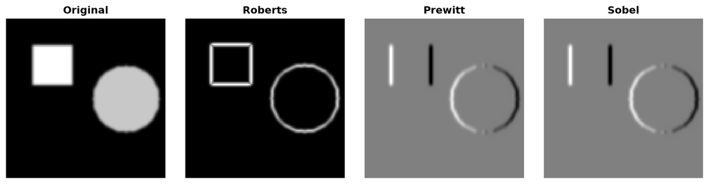

## 4 Método Sobel

- Usa máscaras convolucionales para aproximar derivadas.
- Filtrando con $S_x, S_y$ se obtienen los bordes en X e Y.
- Luego se calcula la magnitud del gradiente.

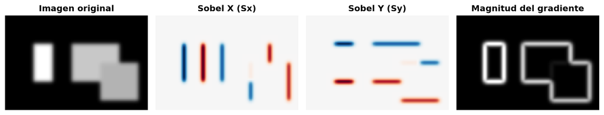

## 5 Método Canny

1. Suavizado con filtro gaussiano.
2. Cálculo de gradientes.
3. **No-maximum suppression** (adelgaza bordes).
4. **Hysteresis thresholding** (clasifica píxeles como borde fuerte, débil o no borde).

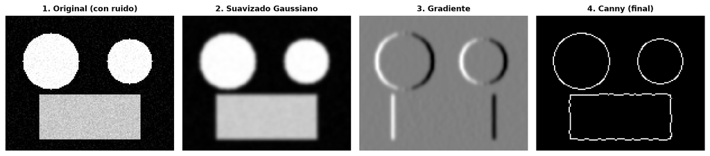

### 5.1 Profundización: NMS e histéresis

**1) No-maximum suppression (NMS)**

- Tras calcular la magnitud del gradiente $G(x,y)$ y su dirección $\theta(x,y)$, se busca la **cresta local** del borde.
- Para cada píxel, se cuantiza $\theta$ (usualmente a $0^\circ, 45^\circ, 90^\circ, 135^\circ$) y se compara $G(x,y)$ con sus 2 vecinos sobre esa dirección.
- Si $G(x,y)$ no es mayor que ambos vecinos, se suprime (se pone en 0).

En forma compacta:

$$G_{NMS}(x,y)=
\begin{cases}
G(x,y), & \text{si } G(x,y) \text{ es máximo local en } \theta(x,y)\\
0, & \text{en otro caso}
\end{cases}$$

Resultado: bordes más finos (casi de 1 píxel de ancho) y mejor localizados.

**2) Hysteresis thresholding**

- Se usan dos umbrales: $T_H$ (alto) y $T_L$ (bajo), con $T_H > T_L$.
- Clasificación inicial:
  - **Fuerte**: $G_{NMS} \ge T_H$
  - **Débil**: $T_L \le G_{NMS} < T_H$
  - **No borde**: $G_{NMS} < T_L$
- Regla de histéresis: un píxel débil se conserva **solo si está conectado** (8-conectividad) a algún píxel fuerte; si no, se elimina.

Intuición didáctica:

- NMS responde: *¿dónde está exactamente la cresta del borde?*
- Histéresis responde: *¿esa cresta pertenece a un contorno real o a ruido?*

## 6 Comparación visual

- Roberts y Prewitt: simples, pero sensibles al ruido.
- Sobel: rápido y más robusto.
- Canny: más elaborado, produce bordes finos y continuos.

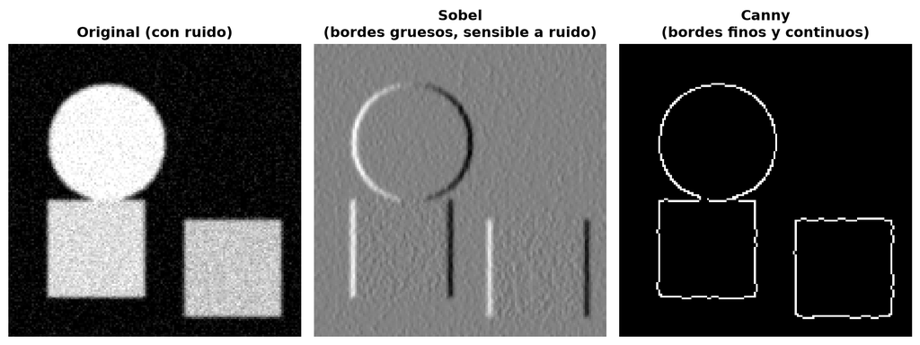

### 6.1 Comparación adicional con imagen real (`frutas.jpg`)

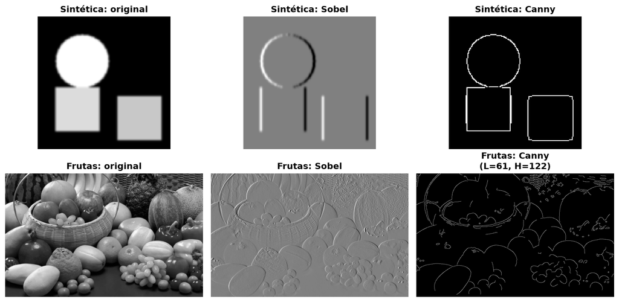

## 7 Ejemplo en Python (OpenCV)

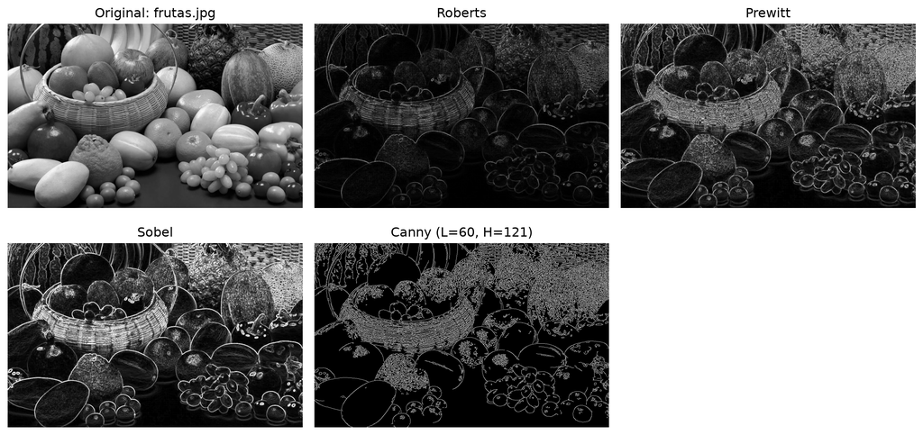

```python
import cv2
import numpy as np
import matplotlib.pyplot as plt

img = cv2.imread("imagenes/frutas.jpg", cv2.IMREAD_GRAYSCALE)

if img is None:
  raise FileNotFoundError("No se encontró la imagen en 'imagenes/frutas.jpg'")

# Roberts
roberts_x = np.array([[1, 0], [0, -1]], dtype=np.float32)
roberts_y = np.array([[0, 1], [-1, 0]], dtype=np.float32)
edges_roberts = cv2.convertScaleAbs(cv2.filter2D(img, cv2.CV_32F, roberts_x)) + \
        cv2.convertScaleAbs(cv2.filter2D(img, cv2.CV_32F, roberts_y))

# Prewitt
prewitt_x = np.array([[-1, 0, 1], [-1, 0, 1], [-1, 0, 1]], dtype=np.float32)
prewitt_y = np.array([[-1, -1, -1], [0, 0, 0], [1, 1, 1]], dtype=np.float32)
edges_prewittx = cv2.convertScaleAbs(cv2.filter2D(img, cv2.CV_32F, prewitt_x)) + \
         cv2.convertScaleAbs(cv2.filter2D(img, cv2.CV_32F, prewitt_y))

# Sobel y Canny
sobel_x = cv2.Sobel(img, cv2.CV_64F, 1, 0, ksize=3)
sobel_y = cv2.Sobel(img, cv2.CV_64F, 0, 1, ksize=3)
edges_sobel = cv2.convertScaleAbs(np.hypot(sobel_x, sobel_y))

# Umbrales automáticos (basados en la mediana)
v = np.median(img)
low = int(max(0, 0.66 * v))
high = int(min(255, 1.33 * v))
edges_canny = cv2.Canny(img, low, high)

plt.figure(figsize=(12, 6))
plt.subplot(2, 3, 1); plt.imshow(img, cmap="gray"); plt.title("Original: frutas.jpg")
plt.subplot(2, 3, 2); plt.imshow(edges_roberts, cmap="gray"); plt.title("Roberts")
plt.subplot(2, 3, 3); plt.imshow(edges_prewittx, cmap="gray"); plt.title("Prewitt")
plt.subplot(2, 3, 4); plt.imshow(edges_sobel, cmap="gray"); plt.title("Sobel")
plt.subplot(2, 3, 5); plt.imshow(edges_canny, cmap="gray"); plt.title(f"Canny (L={low}, H={high})")

for i in range(1, 6):
  plt.subplot(2, 3, i)
  plt.axis("off")

plt.tight_layout()
plt.show()
```

## 8 Aplicaciones

- Segmentación de objetos.
- Reconocimiento de formas.
- Análisis de movimiento.
- Visión en medicina, industria y satélites.

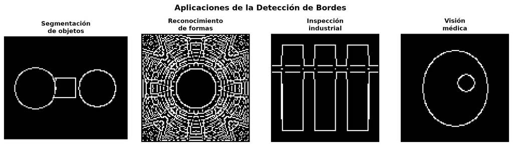